# Parte 1 - ggplot2

Fabrício Dalvi Venturim

12/05/2022

Bibliotecas para o markdown:

```r
library("knitr")
library("kableExtra")
library("htmltools")
```

```r
if(!require(ggplot2)) install.packages("ggplot2")
library(ggplot2)

if(!require(dplyr)) install.packages("dplyr")
library(dplyr)
```

O banco de dados utilizados na parte 1 do trabalho foi:

```r
dados = read.csv("campeonato-brasileiro-full.csv")
```

# 1 Curiosidade e propósito

Assim como no Case Sudy do Capítulo 3 do livro do Andy Kirk, sempre fui fanático por futebol e toda a estatística que busca explicar esse esporte. Nos dias de hoje, o que mais se ouve nas televisões, sites e vídeos são estatísticas e informações sobre o mundo do futebol e suas peculiaridades.

Por conta disso, resolvi pegar um banco de dados sobre o campeonato brasileiro, a fim de realizar algumas análises e tirar conclusões.

## 1.1 Estudar as variáveis do banco de dados

Uma boa forma de iniciar uma análise exploratória de dados é entender e classificar os tipos de variáveis do banco de dados.

Vamos ver o banco de dados:

```r
str(dados)
```

```
## 'data.frame':    7645 obs. of  19 variables:
##  $ ID                : int  1 2 3 4 5 6 7 8 9 10 ...
##  $ rodada            : int  1 1 1 1 1 1 1 1 1 1 ...
##  $ Temporada         : int  2003 2003 2003 2003 2003 2003 2003 2003 2003 2003 ...
##  $ data              : chr  "2003-03-29" "2003-03-29" "2003-03-30" "2003-03-30" ...
##  $ hora              : chr  "16:00" "16:00" "16:00" "16:00" ...
##  $ dia               : chr  "Sabado" "Sabado" "Domingo" "Domingo" ...
##  $ mandante          : chr  "Guarani" "Athletico-PR" "Flamengo" "Goias" ...
##  $ visitante         : chr  "Vasco" "Gremio" "Coritiba" "Paysandu" ...
##  $ formacao_mandante : chr  "" "" "" "" ...
##  $ formacao_visitante: chr  "" "" "" "" ...
##  $ tecnico_mandante  : chr  "" "" "" "" ...
##  $ tecnico_visitante : chr  "" "" "" "" ...
##  $ vencedor          : chr  "Guarani" "Athletico-PR" "-" "-" ...
##  $ arena             : chr  "brinco de ouro" "arena da baixada" "maracana" "serra dourada" ...
##  $ mandante_placar   : int  4 2 1 2 1 2 2 0 2 1 ...
##  $ visitante_placar  : int  2 0 1 2 1 0 2 0 2 1 ...
##  $ mandante_estado   : chr  "SP" "PR" "RJ" "GO" ...
##  $ visitante_estado  : chr  "RJ" "RS" "PR" "PA" ...
##  $ estado_vencedor   : chr  "SP" "PR" "-" "-" ...
```

```r
head(dados)
```

```
##   ID rodada Temporada       data  hora     dia      mandante   visitante
## 1  1      1      2003 2003-03-29 16:00  Sabado       Guarani       Vasco
## 2  2      1      2003 2003-03-29 16:00  Sabado  Athletico-PR      Gremio
## 3  3      1      2003 2003-03-30 16:00 Domingo      Flamengo    Coritiba
## 4  4      1      2003 2003-03-30 16:00 Domingo         Goias    Paysandu
## 5  5      1      2003 2003-03-30 16:00 Domingo Internacional Ponte Preta
## 6  6      1      2003 2003-03-30 16:00 Domingo      Criciuma  Fluminense
##   formacao_mandante formacao_visitante tecnico_mandante tecnico_visitante
## 1
## 2
## 3
## 4
## 5
## 6
##       vencedor            arena mandante_placar visitante_placar
## 1      Guarani   brinco de ouro               4                2
## 2 Athletico-PR arena da baixada               2                0
## 3            -         maracana               1                1
## 4            -    serra dourada               2                2
## 5            -        beira rio               1                1
## 6     Criciuma  heriberto hulse               2                0
##   mandante_estado visitante_estado estado_vencedor
## 1              SP               RJ              SP
## 2              PR               RS              PR
## 3              RJ               PR               -
## 4              GO               PA               -
## 5              RS               SP               -
## 6              SC               RJ              SC
```

```r
tail(dados)
```

```
##        ID rodada Temporada       data  hora     dia   mandante     visitante
## 7640 7640     38      2021 2021-12-12 21:33 Domingo America-MG     Sao Paulo
## 7641 7641     38      2021 2021-12-12 21:33 Domingo Bragantino Internacional
## 7642 7642     38      2021 2021-12-12 21:30 Domingo      Sport  Athletico-PR
## 7643 7643     38      2021 2021-12-12 21:33 Domingo  Juventude   Corinthians
## 7644 7644     38      2021 2021-12-12 21:33 Domingo     Gremio   Atletico-MG
## 7645 7645     38      2021 2021-12-12 21:33 Domingo     Santos        Cuiaba
##      formacao_mandante formacao_visitante    tecnico_mandante
## 7640           4-2-3-1            3-4-1-2             R. Ceni
## 7641           4-2-3-1            3-4-2-1  D. Aguirre Camblor
## 7642           4-2-3-1            3-4-2-1          J. Freitas
## 7643             3-4-3              4-3-3    S. Campos Junior
## 7644           4-2-3-1            4-2-3-1           A. Stival
## 7645           3-4-2-1              4-4-2 J. de Amorim Campos
##        tecnico_visitante   vencedor                    arena mandante_placar
## 7640             R. Ceni America-MG estadio raimundo sampaio               2
## 7641  D. Aguirre Camblor Bragantino                  nabizao               1
## 7642          J. Freitas          -      arena de pernambuco               1
## 7643    S. Campos Junior  Juventude           alfredo jaconi               1
## 7644           A. Stival     Gremio          arena do gremio               4
## 7645 J. de Amorim Campos          -  estadio urbano caldeira               1
##      visitante_placar mandante_estado visitante_estado estado_vencedor
## 7640                0              MG               SP              MG
## 7641                0              SP               RS              SP
## 7642                1              PE               PR               -
## 7643                0              RS               SP              RS
## 7644                3              RS               MG              RS
## 7645                1              SP               MT               -
```

Temos que a classificação das variáveis é a seguinte:

- Qualitativas:
  - `dia`, `mandante`, `visitante`, `vencedor`, `arena`, `mandante_estado`, `visitante_estado`, `estado_vencedor`.
- Quantitativas
  - `rodada`, `temporada`, `hora`, `data`, `mandante_placar`, `visitante_placar`.

Agora que classificamos as variáveis, vamos fazer algumas *análises univariada*

## 1.2 Análise univariada

Como eu peguei esta base da internet, certas variáveis(colunas) não me interessam muito a princípio. Portanto, vou trabalhar com as mais importante, e, caso necessário, utilizo as demais.

### 1.2.1 Variável Qualitativa

Com as variáveis `vencedor`, `arena`, `estado_vencedor`podemos obter, a princípio, uma tabela de frequência:

```r
vencedor.tb <- table(dados$vencedor)
vencedor.tb <- sort(vencedor.tb, decreasing = TRUE)
vencedor.tb
```

```
##
##               -       Sao Paulo        Flamengo          Santos   Internacional
##            2015             338             317             317             304
##     Corinthians          Gremio     Atletico-MG        Cruzeiro       Palmeiras
##             296             295             293             293             286
##      Fluminense    Athletico-PR     Botafogo-RJ           Vasco           Goias
##             285             279             214             196             189
##        Coritiba     Figueirense           Sport         Vitoria           Bahia
##             169             142             131             123             115
##     Ponte Preta          Parana       Juventude       Fortaleza     Chapecoense
##             114              83              82              78              70
##           Ceara     Sao Caetano     Atletico-GO            Avai         Nautico
##              65              65              64              57              54
##        Criciuma        Paysandu      America-MG         Guarani      Portuguesa
##              50              41              38              36              31
##      Bragantino      Santa Cruz         Barueri     Santo Andre     Brasiliense
##              27              15              12              11              10
##          Cuiaba        Ipatinga             CSA Gremio Prudente       Joinville
##              10               9               8               7               7
##      America-RN
##               4
```

Porcentagem:

```r
vencedor.tb/length(dados$vencedor) * 100
```

```
##
##               -       Sao Paulo        Flamengo          Santos   Internacional
##     26.35709614      4.42119032      4.14650098      4.14650098      3.97645520
##     Corinthians          Gremio     Atletico-MG        Cruzeiro       Palmeiras
##      3.87181164      3.85873120      3.83257031      3.83257031      3.74100719
##      Fluminense    Athletico-PR     Botafogo-RJ           Vasco           Goias
##      3.72792675      3.64944408      2.79921517      2.56376717      2.47220405
##        Coritiba     Figueirense           Sport         Vitoria           Bahia
##      2.21059516      1.85742315      1.71353826      1.60889470      1.50425114
##     Ponte Preta          Parana       Juventude       Fortaleza     Chapecoense
##      1.49117070      1.08567691      1.07259647      1.02027469      0.91563113
##           Ceara     Sao Caetano     Atletico-GO            Avai         Nautico
##      0.85022891      0.85022891      0.83714846      0.74558535      0.70634402
##        Criciuma        Paysandu      America-MG         Guarani      Portuguesa
##      0.65402224      0.53629823      0.49705690      0.47089601      0.40549379
##      Bragantino      Santa Cruz         Barueri     Santo Andre     Brasiliense
##      0.35317201      0.19620667      0.15696534      0.14388489      0.13080445
##          Cuiaba        Ipatinga             CSA Gremio Prudente       Joinville
##      0.13080445      0.11772400      0.10464356      0.09156311      0.09156311
##      America-RN
##      0.05232178
```

Vamos plotar um gráfico para ter essas informaçoes visualmente:

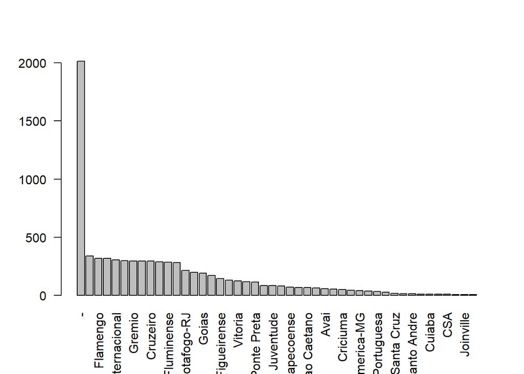

```r
                          #Deixa os times nos eixos em vertical
barplot(vencedor.tb,las = 2, cex.names = 1)
```

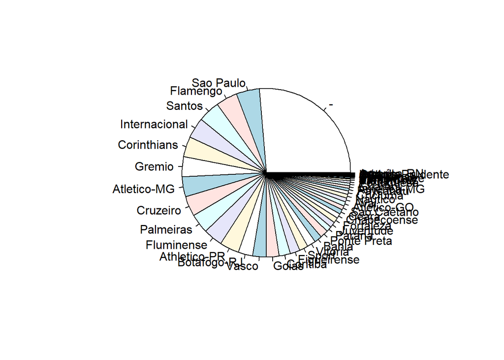

```r
pie(vencedor.tb)
```

Percebe-se que não ficou muito legal de visualizar por conta da quantidade de times. Então, vamos ver apenas os times com mais vitórias.

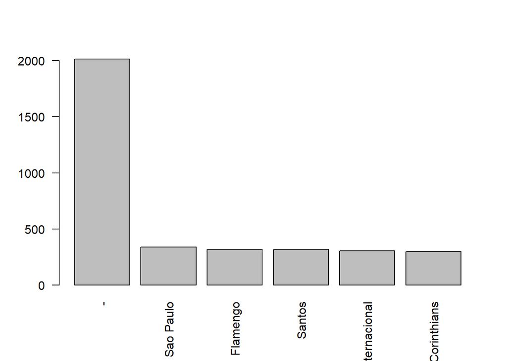

```r
                          #Deixa os times nos eixos em vertical
barplot(head(vencedor.tb), las = 2, cex.names = 1)
```

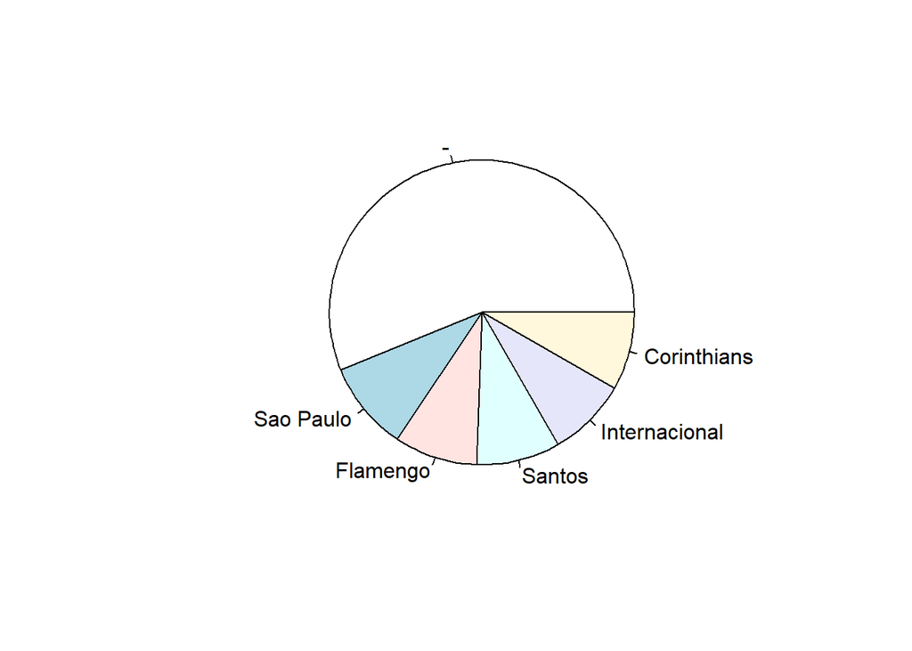

```r
pie(head(vencedor.tb))
```

*Percebe-se que, desconsiderando a quantidade de empates (-), os times que mais venceram foram o São Paulo(338), Flamengo(317), Santos(317), Internacional(304) e Corinthians(296).*

*Além disso, de 2003 até 2021, houveram 2015 empates, o que, considerando que tiveram 7645 jogos, representa 26,35% dos resultados dos jogos.*